# Final Project - Análise exploratória de dados

Henrique C. Pasinato

2023-04-15

## Mudando diretório:

```r
setwd("/Users/hpasi/OneDrive/Área de Trabalho/ANÁLISE EXPL. DE DADOS/Projeto final")
```

## Chamando a base de dados:

Base escolhida devido a negativa por parte da empresa em liberar histórico de venda 2022.

```r
df <- readxl::read_excel(file.choose(setwd))
```

## Selecionando variáveis de interesse:

```r
df_gdp <-df[df$country %in% c("Brazil", "Cuba", "Japan", "Italy"), ]
```

## Descrição - Média, Quantis e St.Deviation

Descrição analítica GDP (PIB) per capita

```r
df_gdp %>% dplyr::select(log_gdppc) %>% summarytools::descr() %>% kbl(caption = "Estatísticas Descritivas da variável Real GDP per capita") %>%
  kable_classic(full_width = F, html_font = "Cambria")
```

Estatísticas Descritivas da variável Real GDP per capita

|  | log_gdppc |
| --- | --- |
| Mean | 8.9761114 |
| Std.Dev | 0.6881637 |
| Min | 7.5838671 |
| Q1 | 8.5497904 |
| Median | 8.8340816 |
| Q3 | 9.6314163 |
| Max | 10.0548496 |
| MAD | 0.8265309 |
| IQR | 1.0353756 |
| CV | 0.0766661 |
| Skewness | -0.1516649 |
| SE.Skewness | 0.4268924 |
| Kurtosis | -1.0070799 |
| N.Valid | 30.0000000 |
| Pct.Valid | 83.3333333 |

## Scatter pré preenchimento de dados

Nota-se que o um melhor GDP per Capita condiz com melhor educação e países de população mais antiga como Japão e Itália.

```r
class(df_gdp)
```

```
## [1] "tbl_df"     "tbl"        "data.frame"
```

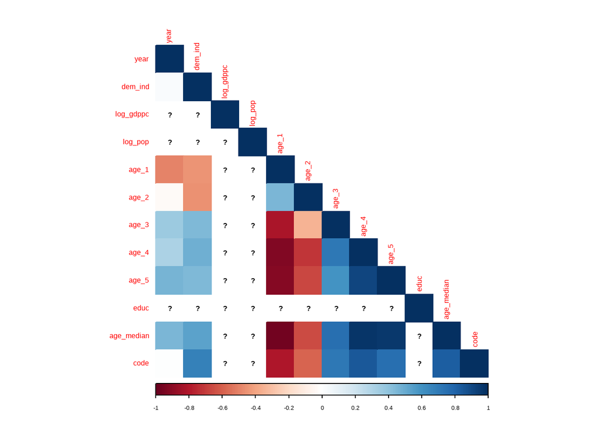

```r
matriz_dados <- as.matrix(df_gdp[, sapply(df_gdp, is.numeric)])

matriz_correlacao <- cor(matriz_dados)

corrplot(matriz_correlacao, method = "color", hc.order=TRUE, type="lower")
```

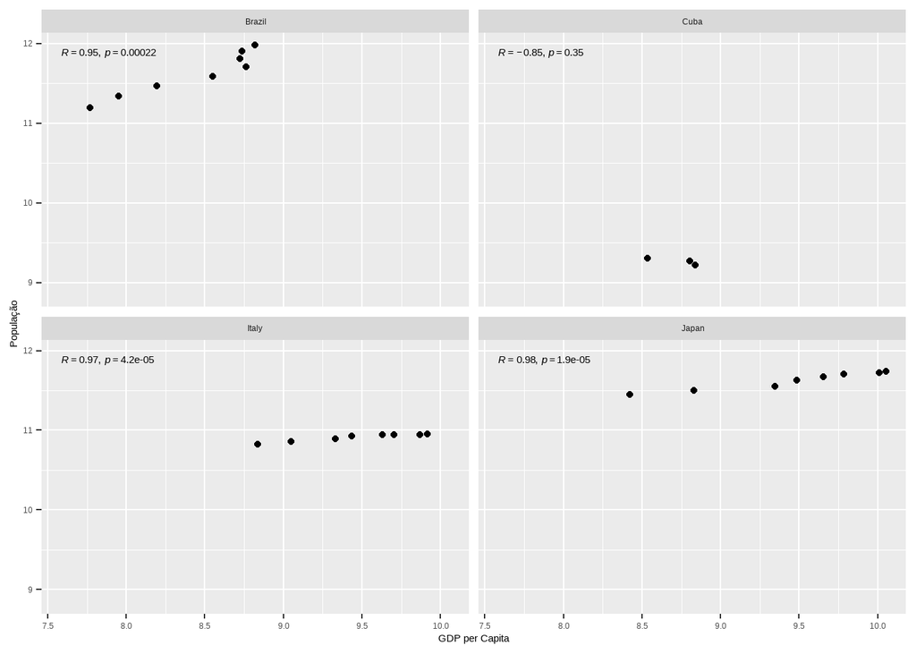

```r
df_gdp %>% ggplot(aes(x = log_gdppc, y = log_pop)) +geom_point() + facet_wrap(~country) + stat_cor(method="pearson") + xlab('GDP per Capita') + ylab('População')
```

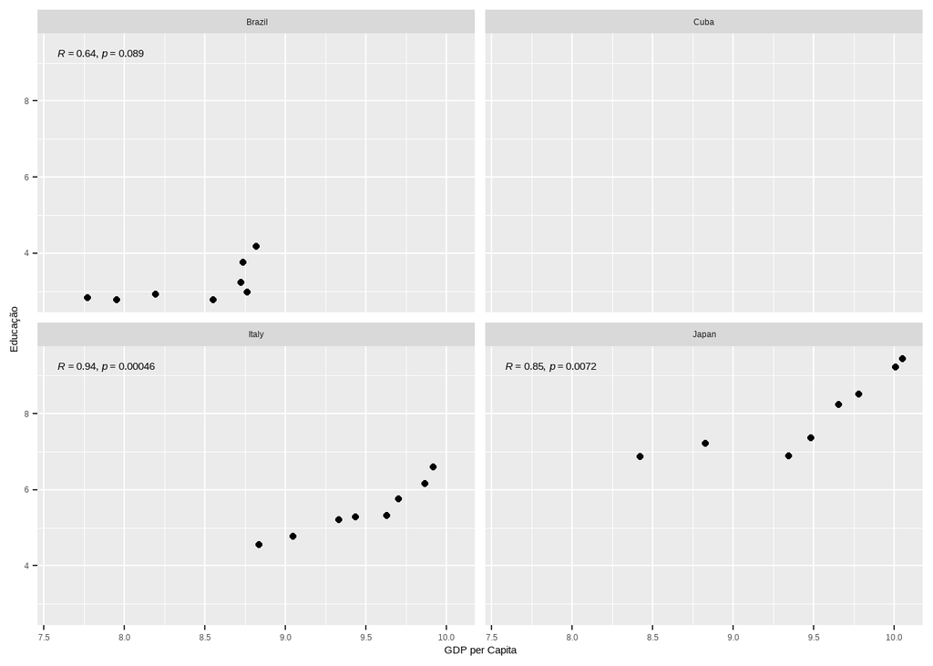

```r
df_gdp %>% ggplot(aes(x = log_gdppc, y = educ)) +geom_point() + facet_wrap(~country) + stat_cor(method="pearson") + xlab('GDP per Capita') + ylab('Educação')
```

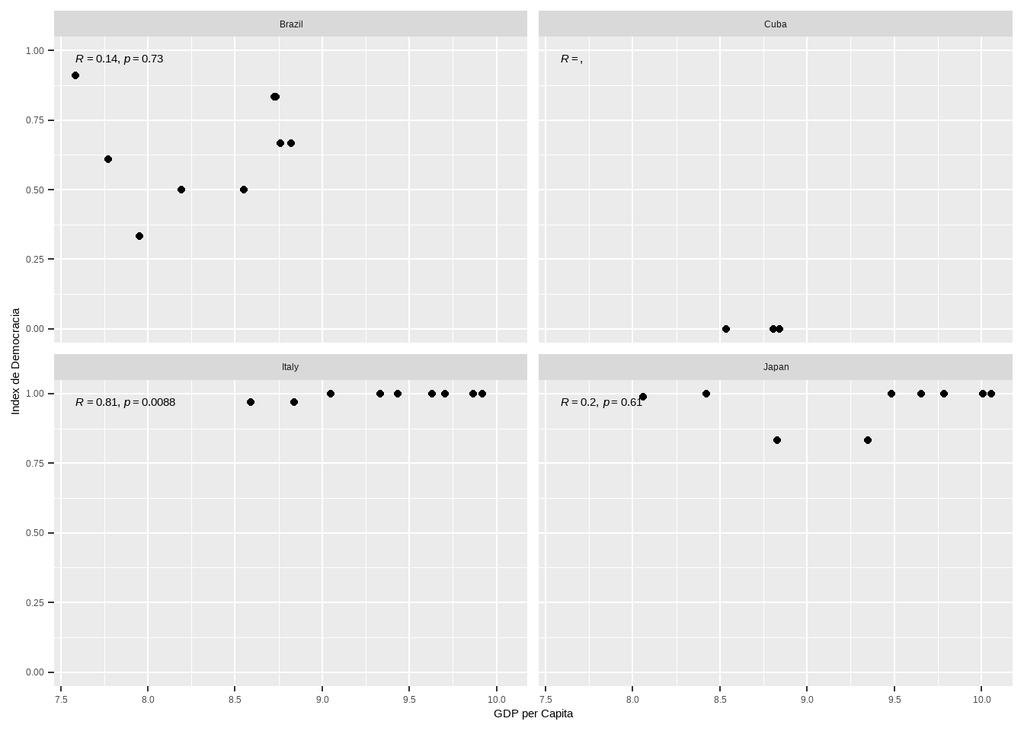

```r
df_gdp %>% ggplot(aes(x = log_gdppc, y = dem_ind)) +geom_point() + facet_wrap(~country) + stat_cor(method="pearson") + xlab('GDP per Capita') + ylab('Index de Democracia')
```

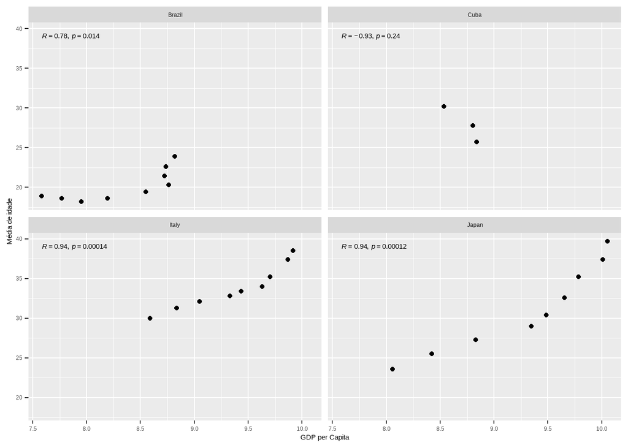

```r
df_gdp %>% ggplot(aes(x = log_gdppc, y = age_median)) +geom_point() + facet_wrap(~country) + stat_cor(method="pearson") + xlab('GDP per Capita') + ylab('Média de idade')
```

## Sobre a normalidade das variáveis:

Distribuição normal é caracterizada por uma curva em forma de sino onde, a maioria dos valores se concentra perto da média, e a proporção de valores que estão a uma certa distância do centro segue o padrão da regra empírica.

No caso desta base em seu formato pré tratamento de NaN, não nos aproximamos de uma normal.

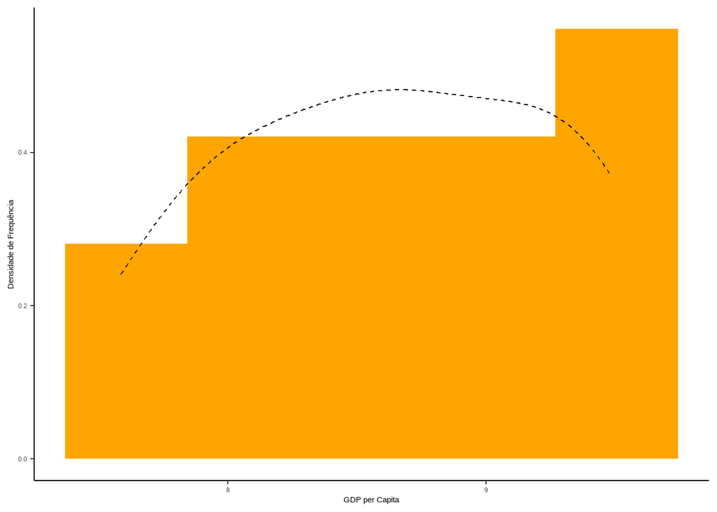

```r
df_gdp %>% dplyr::filter(year <= "1980") %>% ggplot(aes(x=log_gdppc))+geom_histogram(aes(y = after_stat(density)) ,bins = 5, fill = 'orange') + xlab('GDP per Capita') + ylab('Densidade de Frequência') + geom_vline(xintercept=c(median(df_gdp$log_gdppc), mean(df_gdp$log_gdppc))) + annotate("text", x=median(df_gdp$log_gdppc) + 0.3, y=0.05, label="Mediana", angle=90) + annotate("text", x=mean(df_gdp$log_gdppc) + 0.3, y=0.05, label="Média", angle=90) + geom_density(linetype = 2) + theme_classic()
```

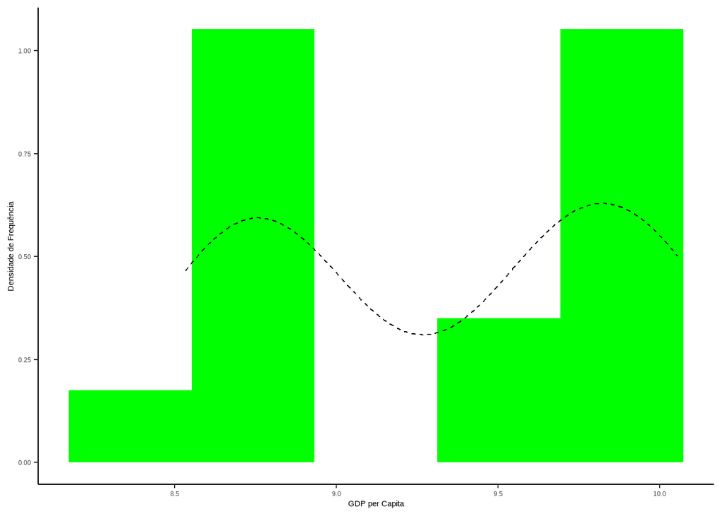

```r
df_gdp %>% dplyr::filter(year >= "1985") %>% ggplot(aes(x=log_gdppc))+geom_histogram(aes(y = after_stat(density)) ,bins = 5, fill = 'green') + xlab('GDP per Capita') + ylab('Densidade de Frequência') + geom_vline(xintercept=c(median(df_gdp$log_gdppc), mean(df_gdp$log_gdppc))) + annotate("text", x=median(df_gdp$log_gdppc) + 0.3, y=0.05, label="Mediana", angle=90) + annotate("text", x=mean(df_gdp$log_gdppc) + 0.3, y=0.05, label="Média", angle=90) + geom_density(linetype = 2) + theme_classic()
```

- Crie um gráfico Q-Q para cada variável de sua base de dados. (use as funções presentes no pacote ggpubr);

Razoavelmente normal a distribuição da base em sua variável objetivo.

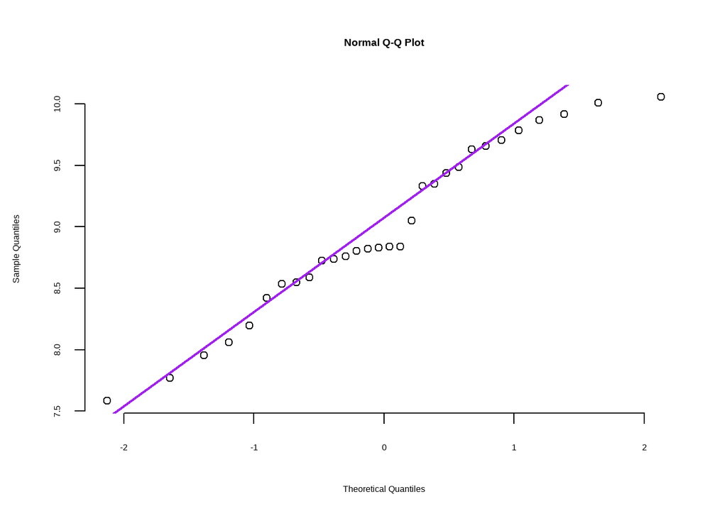

```r
qqnorm(df_gdp$log_gdppc, pch = 1, frame = FALSE)
qqline(df_gdp$log_gdppc, col = "purple", lwd = 2)
```

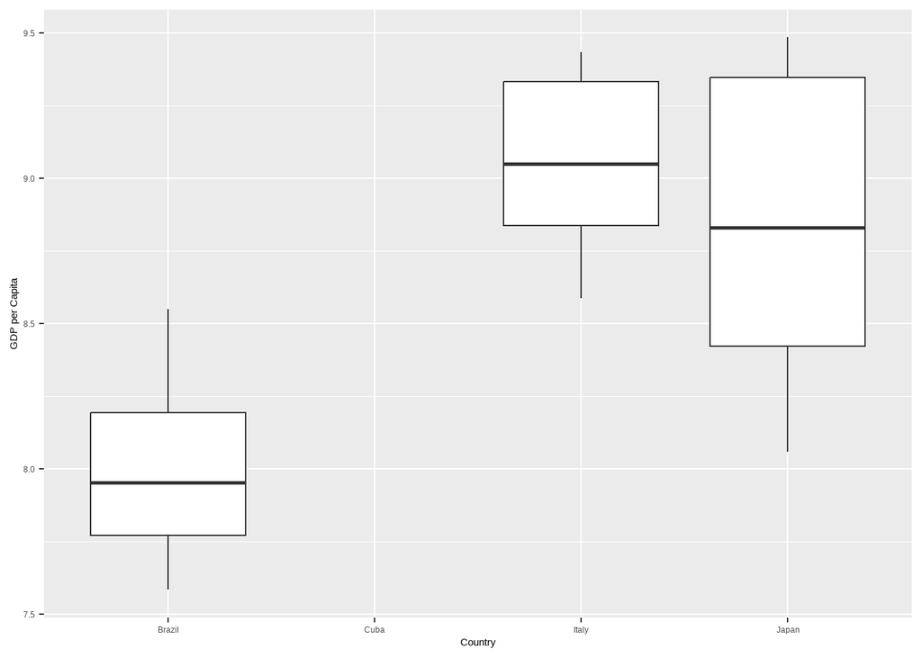

```r
df_gdp %>% dplyr::filter(year <= "1980") %>% ggplot(aes(x = as.factor(country))) + geom_boxplot(aes(y = log_gdppc)) + xlab('Country') + ylab('GDP per Capita')
```

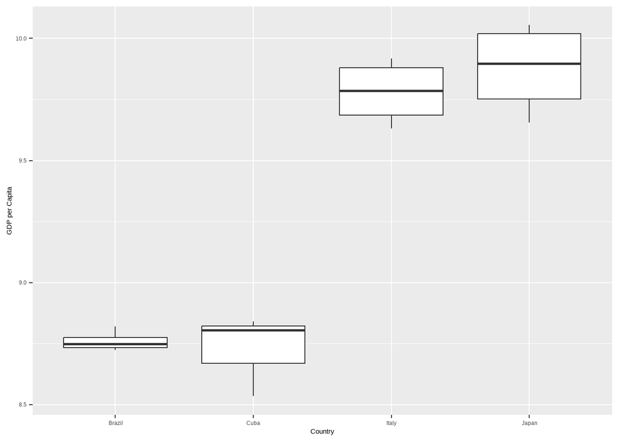

```r
df_gdp %>% dplyr::filter(year >= "1985") %>% ggplot(aes(x = as.factor(country))) + geom_boxplot(aes(y = log_gdppc)) + xlab('Country') + ylab('GDP per Capita')
```

- Execute um teste de normalidade Shapiro-Wilk;

```r
perOne <- df_gdp %>% dplyr::filter(year <= "1980")
shapiro.test(perOne$log_gdppc)
```

```
##
##  Shapiro-Wilk normality test
##
## data:  perOne$log_gdppc
## W = 0.94513, p-value = 0.4512
```

```r
perTwo <- df_gdp %>% dplyr::filter(year >= "1985")
shapiro.test(perTwo$log_gdppc)
```

```
##
##  Shapiro-Wilk normality test
##
## data:  perTwo$log_gdppc
## W = 0.82907, p-value = 0.008899
```

## Qualidade de dados tem sido um dos temas mais abordados nos projetos de estruturação em data analytics, sendo um dos principais indicadores do nível de maturidade das organizações. Um dos problemas mais comuns de qualidade é relacionado à completude de dados. Em suas palavras, como é definido completude? Qual o impacto em uma análise exploratória de dados?

Um database é completo quando todas as informações importantes estão presentes e foram devidamente registradas, facilitando análises de maior acurácia. Dados incompletos podem levar a conclusões erradas e à rejeição de hipóteses que podem ser verdadeiras, nublando a descoberta cientifica.

## Qual a completude para cada uma das variáveis do seu banco de dados?

Nota-se que temos NaN presentes em todos países quanto a sua população no ano de 1960, logo trata-se de dados faltantes não aleatorios (MNAR) e no caso de Cuba constam missings em relaçao ao GDP e Educação não estando relacionados a nenhuma característica específica do país.

```r
summary(df_gdp)
```

```
##    country               year         dem_ind         log_gdppc
##  Length:36          Min.   :1960   Min.   :0.0000   Min.   : 7.584
##  Class :character   1st Qu.:1970   1st Qu.:0.2917   1st Qu.: 8.559
##  Mode  :character   Median :1980   Median :0.8333   Median : 8.834
##                     Mean   :1980   Mean   :0.6659   Mean   : 8.976
##                     3rd Qu.:1990   3rd Qu.:1.0000   3rd Qu.: 9.595
##                     Max.   :2000   Max.   :1.0000   Max.   :10.055
##                                                     NA's   :6
##     log_pop           age_1            age_2            age_3
##  Min.   : 8.852   Min.   :0.1495   Min.   :0.2066   Min.   :0.1597
##  1st Qu.:10.443   1st Qu.:0.2343   1st Qu.:0.2308   1st Qu.:0.1753
##  Median :11.075   Median :0.2624   Median :0.2535   Median :0.1976
##  Mean   :10.820   Mean   :0.2920   Mean   :0.2538   Mean   :0.1960
##  3rd Qu.:11.636   3rd Qu.:0.3611   3rd Qu.:0.2768   3rd Qu.:0.2119
##  Max.   :11.980   Max.   :0.4369   Max.   :0.3156   Max.   :0.2415
##  NA's   :4
##      age_4             age_5              educ         age_median
##  Min.   :0.09427   Min.   :0.05039   Min.   :2.777   Min.   :18.20
##  1st Qu.:0.11500   1st Qu.:0.07349   1st Qu.:3.627   1st Qu.:22.68
##  Median :0.13856   Median :0.10717   Median :5.303   Median :26.50
##  Mean   :0.14407   Mean   :0.11415   Mean   :5.535   Mean   :27.49
##  3rd Qu.:0.17256   3rd Qu.:0.14669   3rd Qu.:6.969   3rd Qu.:32.65
##  Max.   :0.21918   Max.   :0.22380   Max.   :9.442   Max.   :39.70
##                                      NA's   :12
##       code
##  Min.   :26.00
##  1st Qu.:38.75
##  Median :66.50
##  Mean   :63.00
##  3rd Qu.:90.75
##  Max.   :93.00
##
```

## Conferindo faltantes

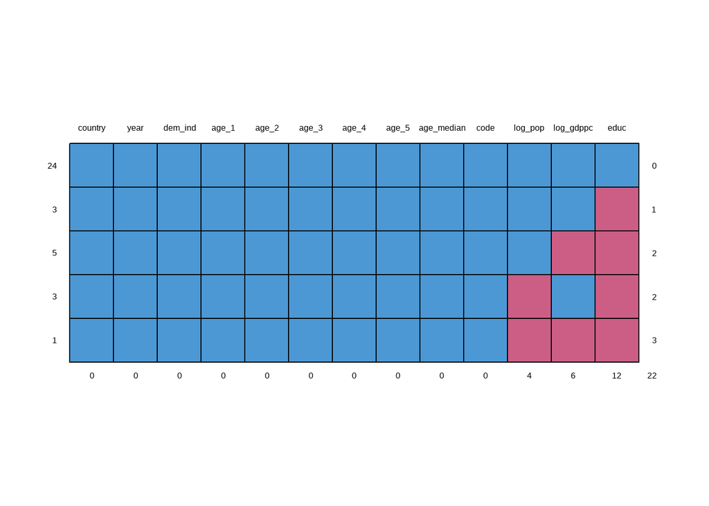

```
##    country year dem_ind age_1 age_2 age_3 age_4 age_5 age_median code log_pop
## 24       1    1       1     1     1     1     1     1          1    1       1
## 3        1    1       1     1     1     1     1     1          1    1       1
## 5        1    1       1     1     1     1     1     1          1    1       1
## 3        1    1       1     1     1     1     1     1          1    1       0
## 1        1    1       1     1     1     1     1     1          1    1       0
##          0    0       0     0     0     0     0     0          0    0       4
##    log_gdppc educ
## 24         1    1  0
## 3          1    0  1
## 5          0    0  2
## 3          1    0  2
## 1          0    0  3
##            6   12 22
```

## Realize uma operação de imputação de dados usando o pacote MICE.

```r
imputed_data <- mice(df_gdp, method = "pmm", m = 5, maxit = 20, seed=123)


finished_imputed_data <- complete(imputed_data, mean(1:5))
```

## Scatter após preenchimento de dados

```r
class(df_gdp)
```

```
## [1] "tbl_df"     "tbl"        "data.frame"
```

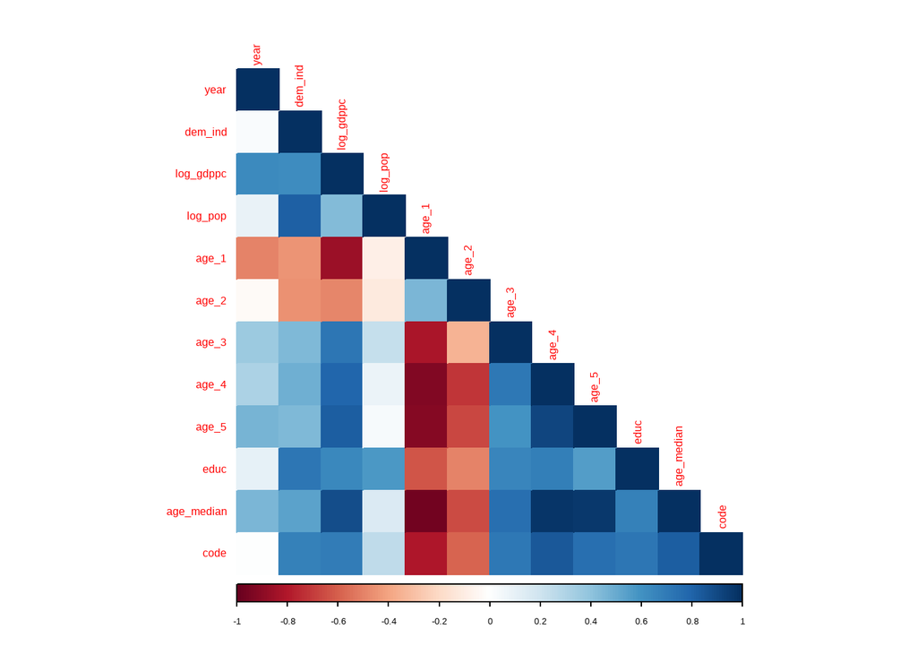

```r
matriz_dados <- as.matrix(finished_imputed_data[, sapply(finished_imputed_data, is.numeric)])

matriz_correlacao <- cor(matriz_dados)

corrplot(matriz_correlacao, method = "color", type="lower")
```

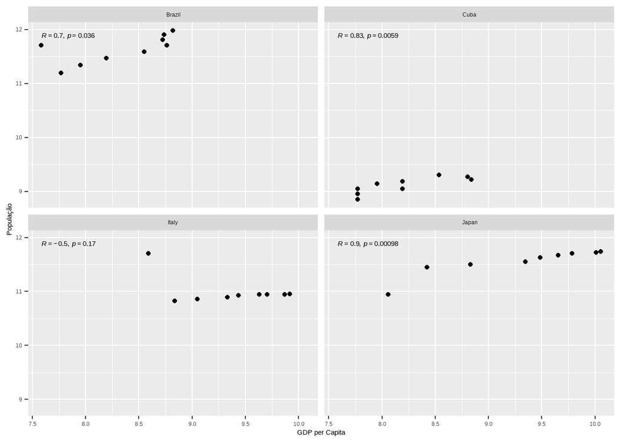

```r
finished_imputed_data %>% ggplot(aes(x = log_gdppc, y = log_pop)) +geom_point() + facet_wrap(~country) + stat_cor(method="pearson") + xlab('GDP per Capita') + ylab('População')
```

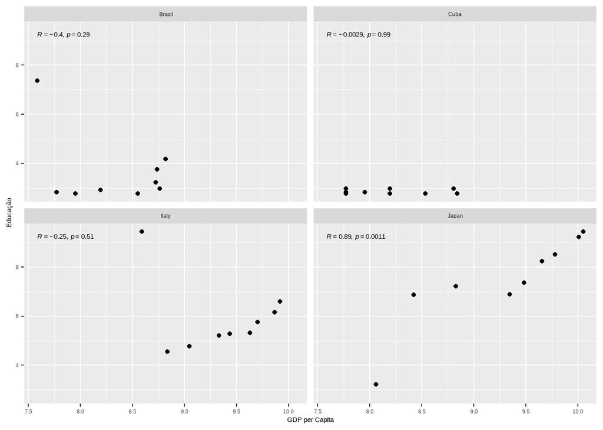

```r
finished_imputed_data %>% ggplot(aes(x = log_gdppc, y = educ)) +geom_point() + facet_wrap(~country) + stat_cor(method="pearson") + xlab('GDP per Capita') + ylab('Educação')
```

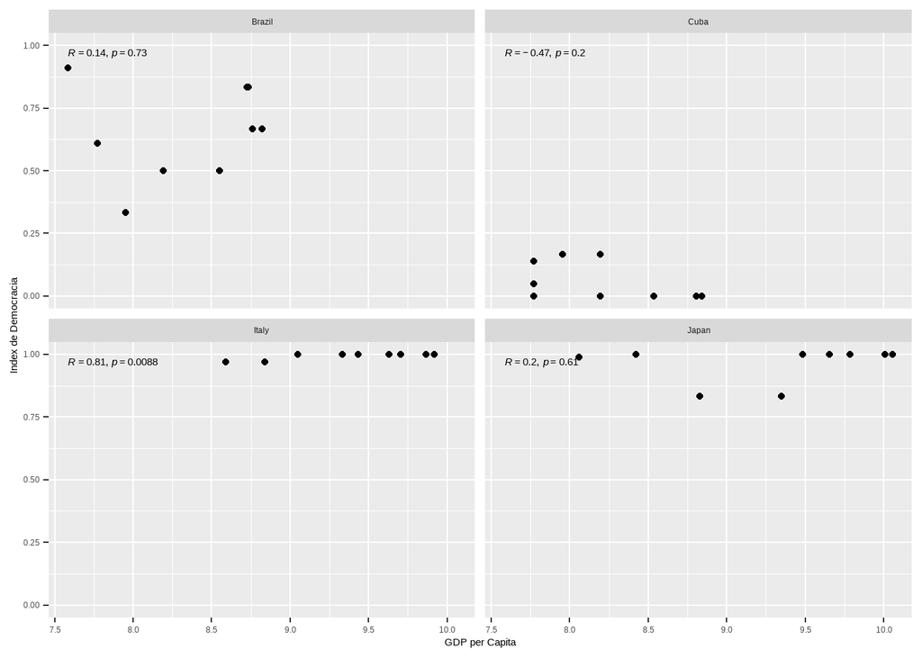

```r
finished_imputed_data %>% ggplot(aes(x = log_gdppc, y = dem_ind)) +geom_point() + facet_wrap(~country) + stat_cor(method="pearson") + xlab('GDP per Capita') + ylab('Index de Democracia')
```

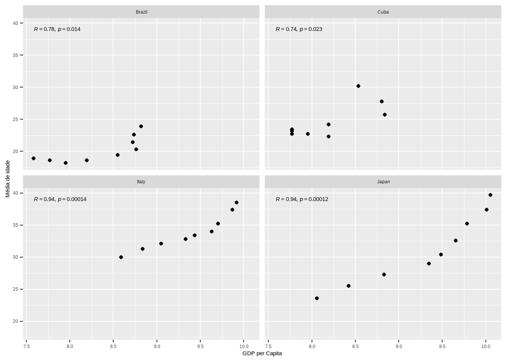

```r
finished_imputed_data %>% ggplot(aes(x = log_gdppc, y = age_median)) +geom_point() + facet_wrap(~country) + stat_cor(method="pearson") + xlab('GDP per Capita') + ylab('Média de idade')
```

## Histograma após preenchimendo de dados

Ficou estranho, provávelmente errei em algo do imput mas não sei identificar no momento.

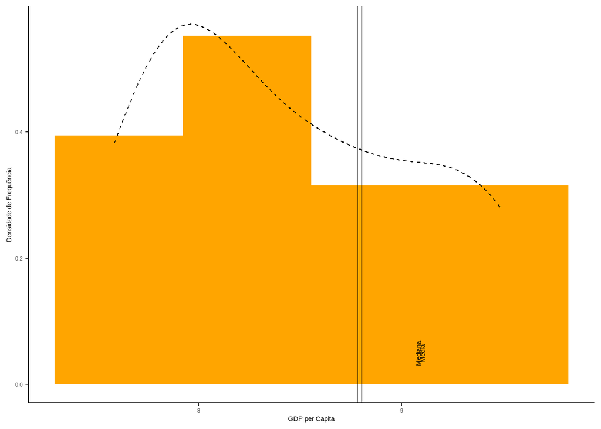

```r
finished_imputed_data %>% dplyr::filter(year <= "1980") %>% ggplot(aes(x=log_gdppc))+geom_histogram(aes(y = after_stat(density)) ,bins = 4, fill = 'orange') + xlab('GDP per Capita') + ylab('Densidade de Frequência') + geom_vline(xintercept=c(median(finished_imputed_data$log_gdppc), mean(finished_imputed_data$log_gdppc))) + annotate("text", x=median(finished_imputed_data$log_gdppc) + 0.3, y=0.05, label="Mediana", angle=90) + annotate("text", x=mean(finished_imputed_data$log_gdppc) + 0.3, y=0.05, label="Média", angle=90) + geom_density(linetype = 2) + theme_classic()
```

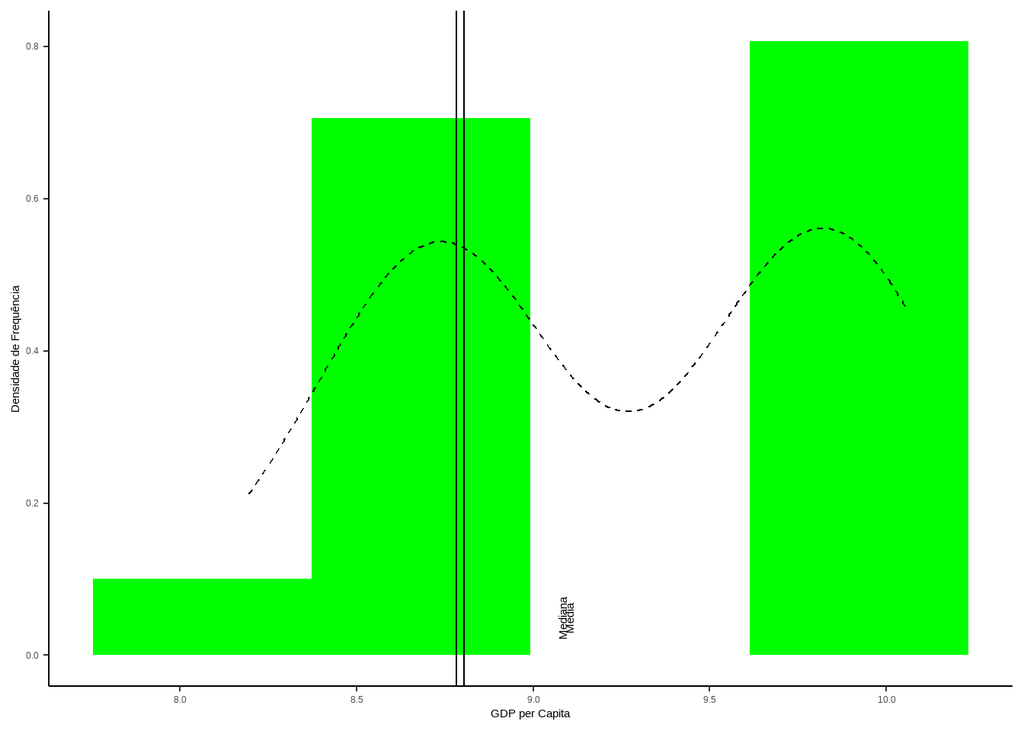

```r
finished_imputed_data %>% dplyr::filter(year >= "1985") %>% ggplot(aes(x=log_gdppc))+geom_histogram(aes(y = after_stat(density)) ,bins = 4, fill = 'green') + xlab('GDP per Capita') + ylab('Densidade de Frequência') + geom_vline(xintercept=c(median(finished_imputed_data$log_gdppc), mean(finished_imputed_data$log_gdppc))) + annotate("text", x=median(finished_imputed_data$log_gdppc) + 0.3, y=0.05, label="Mediana", angle=90) + annotate("text", x=mean(finished_imputed_data$log_gdppc) + 0.3, y=0.05, label="Média", angle=90) + geom_density(linetype = 2) + theme_classic()
```

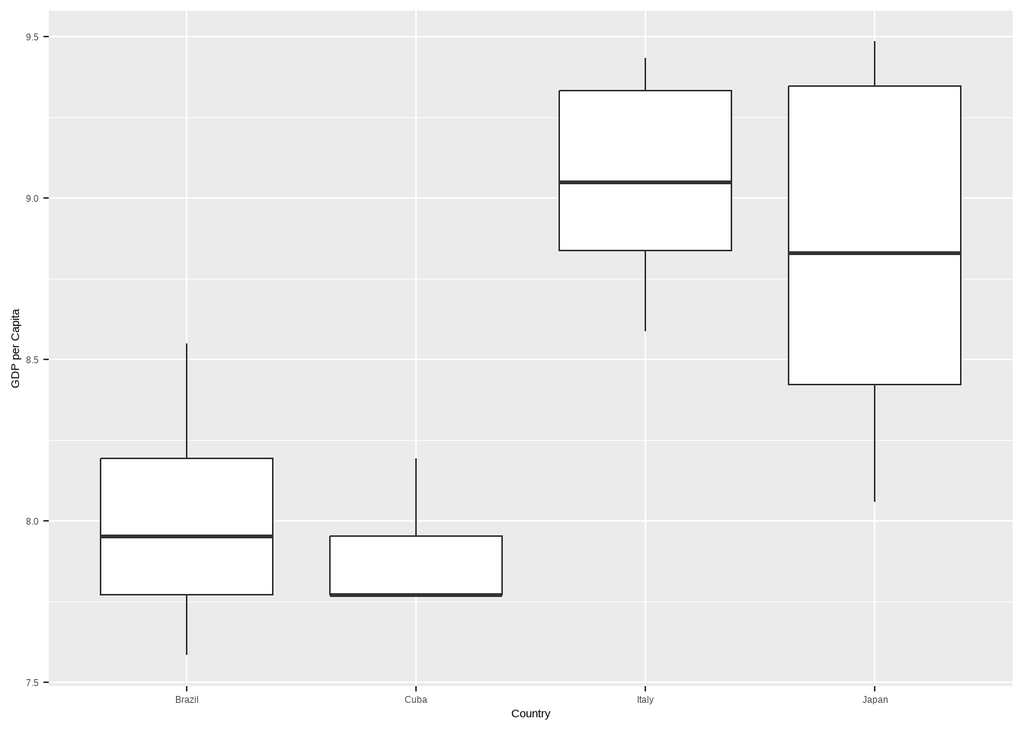

```r
finished_imputed_data %>% dplyr::filter(year <= "1980") %>% ggplot(aes(x = as.factor(country))) + geom_boxplot(aes(y = log_gdppc)) + xlab('Country') + ylab('GDP per Capita')
```

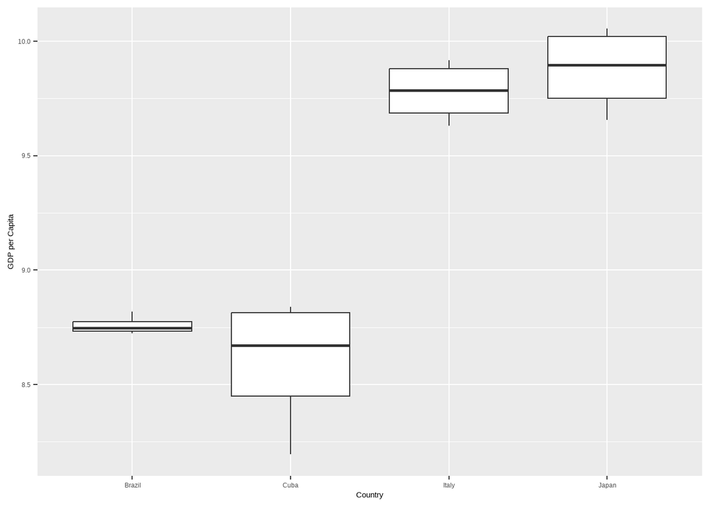

```r
finished_imputed_data %>% dplyr::filter(year >= "1985") %>% ggplot(aes(x = as.factor(country))) + geom_boxplot(aes(y = log_gdppc)) + xlab('Country') + ylab('GDP per Capita')
```

O p-valor é menor que 0,05 em um dos resultados e muito próximo de 0,05 no outro, sugerindo que há evidência suficiente para rejeitar a hipótese nula de normalidade em uma das amostras e sugerir fortemente desvio da normalidade na outra.

```r
perOne <- finished_imputed_data %>% dplyr::filter(year <= "1980")
shapiro.test(perOne$log_gdppc)
```

```
##
##  Shapiro-Wilk normality test
##
## data:  perOne$log_gdppc
## W = 0.90897, p-value = 0.06092
```

```r
perTwo <- finished_imputed_data %>% dplyr::filter(year >= "1985")
shapiro.test(perTwo$log_gdppc)
```

```
##
##  Shapiro-Wilk normality test
##
## data:  perTwo$log_gdppc
## W = 0.87116, p-value = 0.02833
```

## GITHUB Repository

Para acessar o código-fonte do projeto, visite [o repositório no GitHub](https://github.com/h0nkz/AEDD.git).